# 1. Question: Please refer the table below to answer below questions:

1. Refer to the above table and find the joint probability of the people who planned to purchase and actually placed an order.
2. Refer to the above table and find the joint probability of the people who planned to purchase and actually placed an order, given that people planned to purchase.

| Planned to purchase Product A | Actually placed and order for Product A- Yes | Actually placed and order for Product A - No | Total |
| --- | --- | --- | --- |
| Yes | 400 | 100 | 500 |
| No | 200 | 1300 | 1500 |
| Total | 600 | 1400 | 2000 |

```python
#import all the necessary libraries
import numpy as np
import scipy.stats as stats
import matplotlib.pyplot as plt
%matplotlib inline
import pandas as pd
import seaborn as sns
import math
```

```python
# the joint probability of the people who planned to purchase and actually placed an order.
#P(Planned_AND_Purchased) = planned_And_purchased/total
planned_And_purchased = 400
total=2000
P=planned_And_purchased/total
P
```

```
0.2
```

```python
#the joint probability of the people who planned to purchase and actually placed an order, given that people planned to purchase.
planned_And_purchased = 400
people_planned_to_purchase= 500
p=planned_And_purchased/people_planned_to_purchase
p
```

```
0.8
```

# 2. Question: An electrical manufacturing company conducts quality checks at specified periods on the products it manufactures. Historically, the failure rate for the manufactured item is 5%. Suppose a random sample of 10 manufactured items is selected. Answer the following questions.

A. Probability that none of the items are defective?

B. Probability that exactly one of the items is defective?

C. Probability that two or fewer of the items are defective?

D. Probability that three or more of the items are defective ?

```python
#This is a binomial problem. Each selection is independent of one another, and an item is either defective or it is not defective.

n=10    #(the sample size)
p = 0.05 # (the probability of being defective)
k=np.arange(0,11)
binomial = stats.binom.pmf(k,n,p)
binomial
```

```
array([5.98736939e-01, 3.15124705e-01, 7.46347985e-02, 1.04750594e-02,
       9.64808106e-04, 6.09352488e-05, 2.67259863e-06, 8.03789063e-08,
       1.58642578e-09, 1.85546875e-11, 9.76562500e-14])
```

```python
# A. Probability that none of the items are defective?
#This is a binomial problem. Each selection is independent of one another, and an item is either defective or it is not defective.
# P(x=0) none of the items are defective
# p = 0.05   # (the probability of being defective)
# q=(1-p)  # (the probability of not being defective)
# n = 10 #(the sample size)
# x=0
# (math.factorial(n)/(math.factorial(x)*math.factorial(n-x))) * (p**x) * (q**(n-x))
```

```python
# A. Probability that none of the items are defective?
binomial[0]
```

```
0.5987369392383789
```

```python
#B. Probability that exactly one of the items is defective?
# P(x=1) exactly one of the items is defective
# x=1
# (math.factorial(n)/(math.factorial(x)*math.factorial(n-x))) * (p**x) * (q**(n-x))   (Traditional Binomial Formula)
```

```python
#B. Probability that exactly one of the items is defective?
binomial[1]
```

```
0.31512470486230504
```

```python
#C. Probability that two or fewer of the items are defective?
# P(x<=2) two or fewer of the items are defective
# P(x<=2)=P(0) + P(1) + P(2)
# P_0= 0.5987369392383787
# P_1= 0.31512470486230454
# P_2 = (math.factorial(n)/(math.factorial(2)*math.factorial(n-2))) * (p**2) * (q**(n-2))
# P_0 + P_1 + P_2
```

```python
cbinomial = stats.binom.cdf(k,n,p)
cbinomial
```

```
array([0.59873694, 0.91386164, 0.98849644, 0.9989715 , 0.99993631,
       0.99999725, 0.99999992, 1.        , 1.        , 1.        ,
       1.        ])
```

```python
#C. Probability that two or fewer of the items are defective?
# P(x<=2) two or fewer of the items are defective
cbinomial[2]
```

```
0.9884964426207031
```

```python
#D. Probability that three or more of the items are defective ?
# P(x=>3) =1 - P(x<3) = 1 - (P(0)+P(1)+P(2))
# 1-(P_0+P_1+P_2)
```

```python
#D. Probability that three or more of the items are defective ?
# P(x=>3) =1 - P(x<3) = 1 - (P(0)+P(1)+P(2))
1-cbinomial[2]
```

```
0.01150355737929687
```

# 3. Question: A car salesman sells on an average 3 cars per week.

A. Probability that in a given week he will sell some cars.

B. Probability that in a given week he will sell 2 or more but less than 5 cars.

C. Plot the poisson distribution function for cumulative probability of cars sold per-week vs number of cars sold perweek.

```python
#average rate, for poisson distribution
# Here, λ = 3 (rate)
rate = 3
```

```python
#a numpy array of different no. of successes ranging from 0 to 19 to construct a probability distribution

n=np.arange(0,20)
n
```

```
array([ 0,  1,  2,  3,  4,  5,  6,  7,  8,  9, 10, 11, 12, 13, 14, 15, 16,
       17, 18, 19])
```

```python
# Probability that he will sell zero cars
poisson = stats.poisson.pmf(n,rate)
poisson
```

```
array([4.97870684e-02, 1.49361205e-01, 2.24041808e-01, 2.24041808e-01,
       1.68031356e-01, 1.00818813e-01, 5.04094067e-02, 2.16040315e-02,
       8.10151179e-03, 2.70050393e-03, 8.10151179e-04, 2.20950322e-04,
       5.52375804e-05, 1.27471339e-05, 2.73152870e-06, 5.46305740e-07,
       1.02432326e-07, 1.80762929e-08, 3.01271548e-09, 4.75691918e-10])
```

```python
# A. Probability that in a given week he will sell some cars.
# 1 - Probability that he will sell zero cars
1-poisson[0]
```

```
0.950212931632136
```

```python
#B. Probability that in a given week he will sell 2 or more but less than 5 cars.
# (Probability that he will sell two cars + Probability that he will sell three cars + Probability that he will sell four cars)
(poisson[2] + poisson[3] + poisson[4])
```

```
0.6161149710523164
```

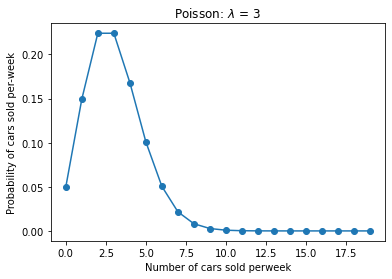

```python
# C. Plot the poisson distribution function for cumulative probability of cars sold per-week vs number of cars sold perweek.
#visualising the plot with pyplot

plt.plot(n,poisson,'o-')
plt.title('Poisson: $\lambda$ = %i ' % rate)
plt.xlabel('Number of cars sold perweek')
plt.ylabel('Probability of cars sold per-week')
plt.show()
```

# 4. Question: Accuracy in understanding orders for a speech based bot at a restaurant is important for the Company X which has designed, marketed and launched the product for a contactless delivery due to the COVID-19 pandemic. Recognition accuracy that measures the percentage of orders that are taken correctly is 86.8%. Suppose that you place order with the bot and two friends of yours independently place orders with the same bot. Answer the following questions.

A. What is the probability that all three orders will be recognised correctly?

B. What is the probability that none of the three orders will be recognised correctly?

C. What is the probability that at least two of the three orders will be recognised correctly?

```python
#A. What is the probability that all three orders will be recognised correctly?
# P(x=3) probability that all three orders will be recognised correctly
# p=0.868  #(the probability of being accuracy)
# q=1-p  #(the probability of being inaccuracy)
# x=3
# n=3
# (n!/x!(n-x)!)*
# (math.factorial(n)/(math.factorial(x)*math.factorial(n-x))) * (p**x) * (q**(n-x))
```

```python
#A. What is the probability that all three orders will be recognised correctly?
# P(x=3) probability that all three orders will be recognised correctly
n=3
p=0.868
k=np.arange(0,4)
binomial = stats.binom.pmf(k,n,p)
binomial
```

```
array([0.00229997, 0.0453721 , 0.2983559 , 0.65397203])
```

```python
binomial[3]
```

```
0.653972032
```

```python
#B. What is the probability that none of the three orders will be recognised correctly?
# P(x=0) probability that none of the three orders will be recognised correctly
# x=0
# P=(math.factorial(n)/(math.factorial(x)*math.factorial(n-x))) * (p**x) * (q**(n-x))
# P
```

```python
#B. What is the probability that none of the three orders will be recognised correctly?
# P(x=0) probability that none of the three orders will be recognised correctly
binomial[0]
```

```
0.002299968
```

```python
#C. What is the probability that at least two of the three orders will be recognised correctly?
# 1-(none of the three orders correct + one of the three orders correct)
1-(binomial[0]+binomial[1])
```

```
0.952327936
```

# 5. Question: A group of 300 professionals sat for a competitive exam. The results show the information of marks obtained by them have a mean of 60 and a standard deviation of 12. The pattern of marks follows a normal distribution. Answer the following questions.

A. What is the percentage of students who score more than 80.

B. What is the percentage of students who score less than 50.

C. What should be the distinction mark if the highest 10% of students are to be awarded distinction?

```python
#A. What is the percentage of students who score more than 80.
#Calculate the z value

z=(80-60)/12
z
stats.norm.cdf(z)
score=1-stats.norm.cdf(80,loc=60,scale=12)
score_more_80=score * 100
score_more_80
```

```
4.77903522728147
```

```python
#B. What is the percentage of students who score less than 50.
score_less_than_50 = (stats.norm.cdf(50,loc=60,scale=12)) * 100
score_less_than_50
```

```
20.232838096364308
```

```python
# C. What should be the distinction mark if the highest 10% of students are to be awarded distinction?
# distinction mark should be 75.4,  if the highest 10% of students are to be awarded distinction
(1-stats.norm.cdf(75.4,loc=60,scale=12)) * 100
distinction_mark = 75.4
distinction_mark
```

```
75.4
```

```python
(1-stats.norm.cdf(75.4,loc=60,scale=12)) * 100
```

```
9.968765962952208
```

# 6. Question: Explain 1 real life industry scenario [other than the ones mentioned above] where you can use the concepts learnt in this module of Applied statistics to get a data driven business solution.

# The Binomial Probability Distribution

A binomial experiment is one that possesses the following properties:

The experiment consists of n repeated trials;

Each trial results in an outcome that may be classified as a success or a failure (hence the name, binomial);

The probability of a success, denoted by p, remains constant from trial to trial and repeated trials are independent.

The number of successes X in n trials of a binomial experiment is called a binomial random variable.

Example of Binomial Distribution Problems in real life industry scenario:

(1) A company owns 400 laptops. Each laptop has an 8% probability of not working. You randomly select 20 laptops for your salespeople.

(a) What is the likelihood that 5 will be broken?

(b) What is the likelihood that they will all work?

(c) What is the likelihood that they will all be broken?

```python
n=20    #(the sample size)
p = 0.08 # (the probability of being defective)
k=np.arange(0,21)
binomial = stats.binom.pmf(k,n,p)
binomial
```

```
array([1.88693329e-01, 3.28162312e-01, 2.71090605e-01, 1.41438577e-01,
       5.22707783e-02, 1.45449122e-02, 3.16193744e-03, 5.49902164e-04,
       7.77035666e-05, 9.00910917e-06, 8.61740877e-07, 6.81218085e-08,
       4.44272664e-09, 2.37737880e-10, 1.03364296e-11, 3.59527985e-13,
       9.76978221e-15, 1.99893242e-16, 2.89700351e-18, 2.65171946e-20,
       1.15292150e-22])
```

```python
#(a) What is the likelihood that 5 will be broken?
binomial[5]
```

```
0.014544912229021888
```

```python
# (b) What is the likelihood that they will all work?
binomial[0]
```

```
0.18869332916279657
```

```python
# (c) What is the likelihood that they will all be broken?
binomial[20]
```

```
1.1529215046068431e-22
```

# PART-2:

• DOMAIN: Sports • CONTEXT: Company X manages the men's top professional basketball division of the American league system. The dataset contains information on all the teams that have participated in all the past tournaments. It has data about how many baskets each team scored, conceded, how many times they came within the first 2 positions, how many tournaments they have qualified, their best position in the past, etc. • DATA DESCRIPTION: Basketball.csv - The data set contains information on all the teams so far participated in all the past tournaments. • ATTRIBUTE INFORMATION:

1. Team: Team’s name
2. Tournament: Number of played tournaments.
3. Score: Team’s score so far.
4. PlayedGames: Games played by the team so far.
5. WonGames: Games won by the team so far.
6. DrawnGames: Games drawn by the team so far.
7. LostGames: Games lost by the team so far.
8. BasketScored: Basket scored by the team so far.
9. BasketGiven: Basket scored against the team so far.
10. TournamentChampion: How many times the team was a champion of the tournaments so far.
11. Runner-up: How many times the team was a runners-up of the tournaments so far.
12. TeamLaunch: Year the team was launched on professional basketball.
13. HighestPositionHeld: Highest position held by the team amongst all the tournaments played. • PROJECT OBJECTIVE: Company’s management wants to invest on proposal on managing some of the best teams in the league. The analytics department has been assigned with a task of creating a report on the performance shown by the teams. Some of the older teams are already in contract with competitors. Hence Company X wants to understand which teams they can approach which will be a deal win for them.

Steps and tasks: [ Total Score: 15 points]

1. Read the data set, clean the data and prepare a final dataset to be used for analysis.
2. Perform detailed statistical analysis and EDA using univariate, bi-variate and multivariate EDA techniques to get a data driven insights on recommending which teams they can approach which will be a deal win for them. Also as a data and statistics expert you have to develop a detailed performance report using this data. Hint: Use statistical techniques and visualisation techniques to come up with useful metrics and reporting. Find out the best performing team, oldest team, team with highest goals, team with lowest performance etc. and many more. These are just random examples please use your best analytical approach to build this report. You can mix match columns to create new ones which can be used for better analysis. Create your own features if required. Be highly experimental and analytical here to find hidden patterns. Use graphical interactive libraries to enable you to publish interactive plots in python.
3. Please include any improvements or suggestions to the association management on quality, quantity, variety, velocity, veracity etc. on the data points collected by the association to perform a better data analysis in future.

```python
# Load the necessary packages
# Already loaded at the begining
```

```python
# Load the Basketball Dataset

Basketball = pd.read_csv('Basketball.csv')
```

```python
# Return the first `n` rows.
Basketball.head(61)
```

|  | Team | Tournament | Score | PlayedGames | WonGames | DrawnGames | LostGames | BasketScored | BasketGiven | TournamentChampion | Runner-up | TeamLaunch | HighestPositionHeld |
| --- | --- | --- | --- | --- | --- | --- | --- | --- | --- | --- | --- | --- | --- |
| 0 | Team 1 | 86 | 4385 | 2762 | 1647 | 552 | 563 | 5947 | 3140 | 33 | 23 | 1929 | 1 |
| 1 | Team 2 | 86 | 4262 | 2762 | 1581 | 573 | 608 | 5900 | 3114 | 25 | 25 | 1929 | 1 |
| 2 | Team 3 | 80 | 3442 | 2614 | 1241 | 598 | 775 | 4534 | 3309 | 10 | 8 | 1929 | 1 |
| 3 | Team 4 | 82 | 3386 | 2664 | 1187 | 616 | 861 | 4398 | 3469 | 6 | 6 | 1931to32 | 1 |
| 4 | Team 5 | 86 | 3368 | 2762 | 1209 | 633 | 920 | 4631 | 3700 | 8 | 7 | 1929 | 1 |
| ... | ... | ... | ... | ... | ... | ... | ... | ... | ... | ... | ... | ... | ... |
| 56 | Team 57 | 1 | 34 | 38 | 8 | 10 | 20 | 38 | 66 | - | - | 2009-10 | 20 |
| 57 | Team 58 | 1 | 22 | 30 | 7 | 8 | 15 | 37 | 57 | - | - | 1956-57 | 16 |
| 58 | Team 59 | 1 | 19 | 30 | 7 | 5 | 18 | 51 | 85 | - | - | 1951~52 | 16 |
| 59 | Team 60 | 1 | 14 | 30 | 5 | 4 | 21 | 34 | 65 | - | - | 1955-56 | 15 |
| 60 | Team 61 | 1 | - | - | - | - | - | - | - | - | - | 2017~18 | 9 |

61 rows × 13 columns

The shape attribute tells us a number of observations and variables we have in the data set. It is used to check the dimension of data. The Basketball data set has 61 observations and 13 variables in the data set.

```python
Basketball.shape
```

```
(61, 13)
```

```python
Basketball.dtypes # WE can check the data types of each columns. All are object type except Tournament and HighestPositionHeld
```

```
Team                   object
Tournament              int64
Score                  object
PlayedGames            object
WonGames               object
DrawnGames             object
LostGames              object
BasketScored           object
BasketGiven            object
TournamentChampion     object
Runner-up              object
TeamLaunch             object
HighestPositionHeld     int64
dtype: object
```

```python
#Print concise summary of Dataframe
#info() is used to check the Information about the data and the datatypes of each respective attribute.
Basketball.info()
```

```
<class 'pandas.core.frame.DataFrame'>
RangeIndex: 61 entries, 0 to 60
Data columns (total 13 columns):
 #   Column               Non-Null Count  Dtype
---  ------               --------------  -----
 0   Team                 61 non-null     object
 1   Tournament           61 non-null     int64
 2   Score                61 non-null     object
 3   PlayedGames          61 non-null     object
 4   WonGames             61 non-null     object
 5   DrawnGames           61 non-null     object
 6   LostGames            61 non-null     object
 7   BasketScored         61 non-null     object
 8   BasketGiven          61 non-null     object
 9   TournamentChampion   61 non-null     object
 10  Runner-up            61 non-null     object
 11  TeamLaunch           61 non-null     object
 12  HighestPositionHeld  61 non-null     int64
dtypes: int64(2), object(11)
memory usage: 6.3+ KB
```

```python
Basketball['HighestPositionHeld'].unique()
```

```
array([ 1,  3,  2,  4,  6,  8,  5, 11,  7, 12, 10, 17,  9, 19, 14, 16, 20,
       15], dtype=int64)
```

```python
wins_per_gamesPlayed = Basketball.groupby("TeamLaunch")["WonGames"].value_counts()
wins_per_gamesPlayed
```

```
TeamLaunch  WonGames
1929        1209        1
            1241        1
            1581        1
            1647        1
            18          1
                       ..
2007-08     62          1
2009-10     8           1
2014-15     35          1
2016_17     8           1
2017~18     -           1
Name: WonGames, Length: 61, dtype: int64
```

```python
# Replace the - in the dataset in the dataframe with 0
Basketball.replace({"-": 0}, inplace=True)
print(Basketball)
```

```
       Team  Tournament Score PlayedGames WonGames DrawnGames LostGames  \
0    Team 1          86  4385        2762     1647        552       563
1    Team 2          86  4262        2762     1581        573       608
2    Team 3          80  3442        2614     1241        598       775
3    Team 4          82  3386        2664     1187        616       861
4    Team 5          86  3368        2762     1209        633       920
..      ...         ...   ...         ...      ...        ...       ...
56  Team 57           1    34          38        8         10        20
57  Team 58           1    22          30        7          8        15
58  Team 59           1    19          30        7          5        18
59  Team 60           1    14          30        5          4        21
60  Team 61           1     0           0        0          0         0

   BasketScored BasketGiven TournamentChampion Runner-up TeamLaunch  \
0          5947        3140                 33        23       1929
```

[output cut: 25 more lines]

```python
# split the symbols in TeamLaunch column and extract the exact year of launch
Basketball['TeamLaunch']=Basketball['TeamLaunch'].str.split('-', expand = True,n=1)
Basketball['TeamLaunch']=Basketball['TeamLaunch'].str.split('~', expand = True,n=1)
Basketball['TeamLaunch']=Basketball['TeamLaunch'].str.split('to', expand = True,n=1)
Basketball['TeamLaunch']=Basketball['TeamLaunch'].str.split('_', expand = True,n=1)
Basketball['TeamLaunch']
```

```
0     1929
1     1929
2     1929
3     1931
4     1929
      ...
56    2009
57    1956
58    1951
59    1955
60    2017
Name: TeamLaunch, Length: 61, dtype: object
```

```python
# Type Cast all the object type data types to integer except Team
Basketball['Score'] = pd.to_numeric(Basketball['Score'])
Basketball['PlayedGames'] = pd.to_numeric(Basketball['PlayedGames'])
Basketball['WonGames'] = pd.to_numeric(Basketball['WonGames'])
Basketball['DrawnGames'] = pd.to_numeric(Basketball['DrawnGames'])
Basketball['LostGames'] = pd.to_numeric(Basketball['LostGames'])
Basketball['BasketScored'] = pd.to_numeric(Basketball['BasketScored'])
Basketball['BasketGiven'] = pd.to_numeric(Basketball['BasketGiven'])
Basketball['TournamentChampion'] = pd.to_numeric(Basketball['TournamentChampion'])
Basketball['Runner-up'] = pd.to_numeric(Basketball['Runner-up'])
Basketball['TeamLaunch'] = pd.to_numeric(Basketball['TeamLaunch'])
```

```python
Basketball.info()
```

```
<class 'pandas.core.frame.DataFrame'>
RangeIndex: 61 entries, 0 to 60
Data columns (total 13 columns):
 #   Column               Non-Null Count  Dtype
---  ------               --------------  -----
 0   Team                 61 non-null     object
 1   Tournament           61 non-null     int64
 2   Score                61 non-null     int64
 3   PlayedGames          61 non-null     int64
 4   WonGames             61 non-null     int64
 5   DrawnGames           61 non-null     int64
 6   LostGames            61 non-null     int64
 7   BasketScored         61 non-null     int64
 8   BasketGiven          61 non-null     int64
 9   TournamentChampion   61 non-null     int64
 10  Runner-up            61 non-null     int64
 11  TeamLaunch           61 non-null     int64
 12  HighestPositionHeld  61 non-null     int64
dtypes: int64(12), object(1)
memory usage: 6.3+ KB
```

```python
# Handling missing value
# Check for missing value in any column
Basketball.isnull().sum()
```

```
Team                   0
Tournament             0
Score                  0
PlayedGames            0
WonGames               0
DrawnGames             0
LostGames              0
BasketScored           0
BasketGiven            0
TournamentChampion     0
Runner-up              0
TeamLaunch             0
HighestPositionHeld    0
dtype: int64
```

```python
# From the above reults we can clearly see that there are No missing values.

# We usually treat the null values with the following techniques:

# Drop the missing values: In this case, we drop the missing values from those variables. In case there are very few missing values we can drop those values.
# Impute with mean value: For the numerical column, we can replace the missing values with mean values. Before replacing with mean value, it is advisable to check that the variable shouldn’t have extreme values .i.e. outliers.
# Impute with median value: For the numerical column, we can also replace the missing values with median values. In case we have extreme values such as outliers it is advisable to use the median approach.
# Impute with mode value: For the categorical column, we can replace the missing values with mode values i.e the frequent ones.
# Remove missing values
# df_Basket = Basketball.dropna()
# df_Basket
```

```python
# Handling Duplicate records
# Check for duplicate data
duplicate = Basketball.duplicated()
print(duplicate.sum())
Basketball[duplicate]
```

```
0
```

|  | Team | Tournament | Score | PlayedGames | WonGames | DrawnGames | LostGames | BasketScored | BasketGiven | TournamentChampion | Runner-up | TeamLaunch | HighestPositionHeld |
| --- | --- | --- | --- | --- | --- | --- | --- | --- | --- | --- | --- | --- | --- |

From the above results we observed that there are no duplicate columns in the data frame

```python
# Generate descriptive statistics.
# Descriptive statistics include those that summarize the central tendency, dispersion and shape of a
# dataset's distribution, excluding ``NaN`` values

Basketball.describe(include="all")
```

|  | Team | Tournament | Score | PlayedGames | WonGames | DrawnGames | LostGames | BasketScored | BasketGiven | TournamentChampion | Runner-up | TeamLaunch | HighestPositionHeld |
| --- | --- | --- | --- | --- | --- | --- | --- | --- | --- | --- | --- | --- | --- |
| count | 61 | 61.000000 | 61.000000 | 61.000000 | 61.000000 | 61.000000 | 61.000000 | 61.000000 | 61.000000 | 61.000000 | 61.000000 | 61.000000 | 61.000000 |
| unique | 61 | NaN | NaN | NaN | NaN | NaN | NaN | NaN | NaN | NaN | NaN | NaN | NaN |
| top | Team 52 | NaN | NaN | NaN | NaN | NaN | NaN | NaN | NaN | NaN | NaN | NaN | NaN |
| freq | 1 | NaN | NaN | NaN | NaN | NaN | NaN | NaN | NaN | NaN | NaN | NaN | NaN |
| mean | NaN | 24.000000 | 901.426230 | 796.819672 | 303.967213 | 188.934426 | 303.754098 | 1140.344262 | 1140.229508 | 1.426230 | 1.409836 | 1958.918033 | 7.081967 |
| std | NaN | 26.827225 | 1134.899121 | 876.282765 | 406.991030 | 201.799477 | 294.708594 | 1506.740211 | 1163.710766 | 5.472535 | 4.540107 | 27.484114 | 5.276663 |
| min | NaN | 1.000000 | 0.000000 | 0.000000 | 0.000000 | 0.000000 | 0.000000 | 0.000000 | 0.000000 | 0.000000 | 0.000000 | 1929.000000 | 1.000000 |
| 25% | NaN | 4.000000 | 96.000000 | 114.000000 | 34.000000 | 24.000000 | 62.000000 | 153.000000 | 221.000000 | 0.000000 | 0.000000 | 1935.000000 | 3.000000 |
| 50% | NaN | 12.000000 | 375.000000 | 423.000000 | 123.000000 | 95.000000 | 197.000000 | 430.000000 | 632.000000 | 0.000000 | 0.000000 | 1951.000000 | 6.000000 |
| 75% | NaN | 38.000000 | 1351.000000 | 1318.000000 | 426.000000 | 330.000000 | 563.000000 | 1642.000000 | 1951.000000 | 0.000000 | 0.000000 | 1978.000000 | 10.000000 |
| max | NaN | 86.000000 | 4385.000000 | 2762.000000 | 1647.000000 | 633.000000 | 1070.000000 | 5947.000000 | 3889.000000 | 33.000000 | 25.000000 | 2017.000000 | 20.000000 |

Various Types of Data Visualization analysis is:

a. Uni Variate analysis: This shows every observation/distribution in data on a single data variable. It can be shown with the help of various plots like Scatter Plot, Line plot, Histogram(summary)plot, box plots, violin plot, etc.

b. Bi-Variate analysis: Bivariate analysis displays are done to reveal the relationship between two data variables. It can also be shown with the help of Scatter plots, histograms, Heat Maps, Box Plots, Violin Plots, etc.

c. Multi-Variate analysis: Multivariate analysis, as the name suggests, displays are done to reveal the relationship between more than two data variables.

Scatterplots, Histograms, box plots, violin plots can be used for Multivariate Analysis

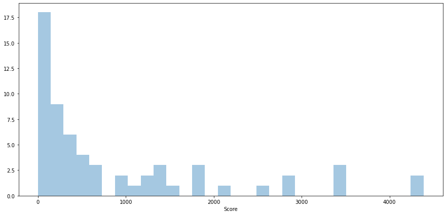

```python
plt.figure(figsize=(15,7));
sns.distplot(Basketball['Score'], kde=False, bins=30)
```

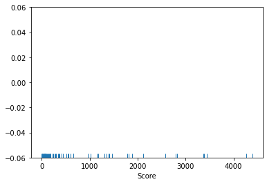

```python
sns.rugplot(Basketball['Score'])
```

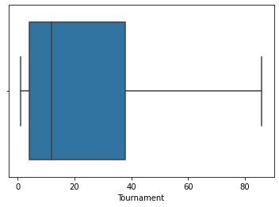

```python
sns.boxplot(x=Basketball['Tournament'])
```

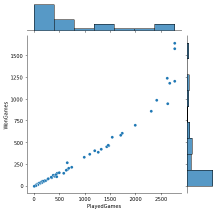

```python
# bivariate
sns.jointplot(x='PlayedGames', y='WonGames', data=Basketball)
```

```
array([[<AxesSubplot:title={'center':'Tournament'}>,
        <AxesSubplot:title={'center':'Score'}>,
        <AxesSubplot:title={'center':'PlayedGames'}>],
       [<AxesSubplot:title={'center':'WonGames'}>,
        <AxesSubplot:title={'center':'DrawnGames'}>,
        <AxesSubplot:title={'center':'LostGames'}>],
       [<AxesSubplot:title={'center':'BasketScored'}>,
        <AxesSubplot:title={'center':'BasketGiven'}>,
        <AxesSubplot:title={'center':'TournamentChampion'}>],
       [<AxesSubplot:title={'center':'Runner-up'}>,
        <AxesSubplot:title={'center':'TeamLaunch'}>,
        <AxesSubplot:title={'center':'HighestPositionHeld'}>]],
      dtype=object)
```

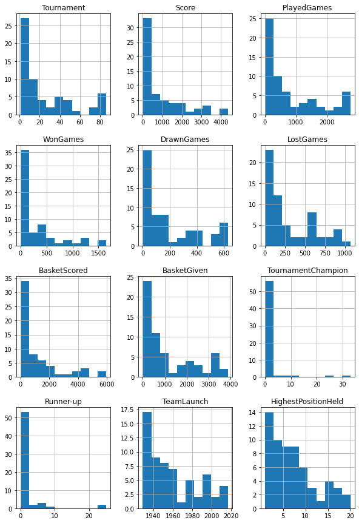

```python
%matplotlib inline

Basketball.hist(figsize=(10,15))
```

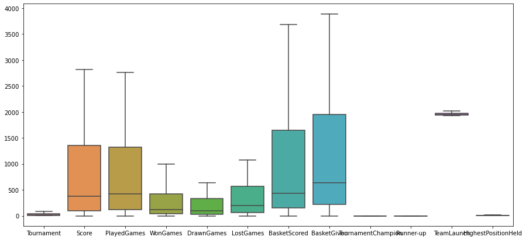

```python
plt.figure(figsize=(15,7));

sns.boxplot(data=Basketball,showfliers=False);
```

A box plot is used for depicting groups of numerical data through their quartiles.

Handling Outlier:

Outliers, being the most extreme observations, may include the sample maximum or sample minimum, or both, depending on whether they are extremely high or low. However, the sample maximum and minimum are not always outliers because they may not be unusually far from other observations.

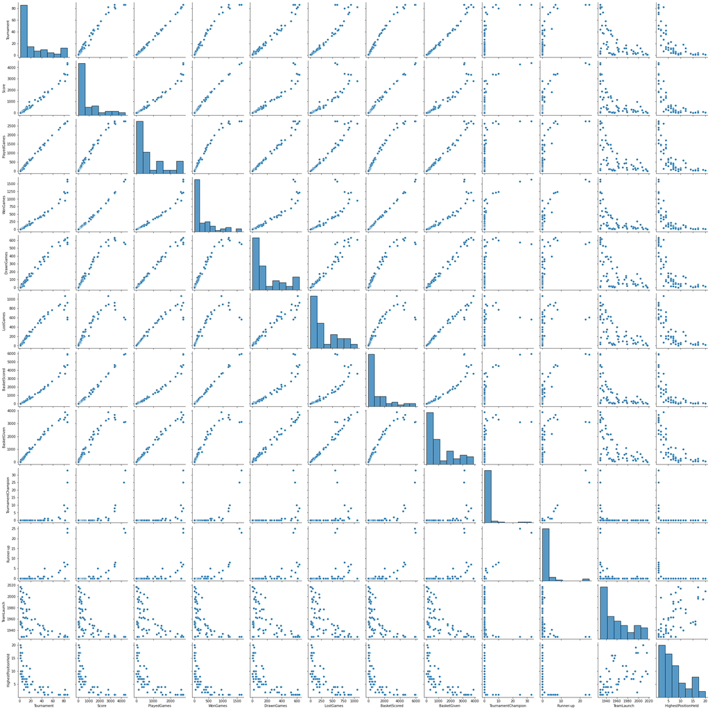

```python
sns.pairplot(Basketball, palette='coolwarm')
```

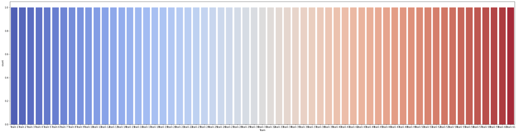

```python
# Bar plots help us visualize the distributions of categorical variables: Countplot is a type of barplot.
plt.figure(figsize=(40,10));
sns.countplot(x=Basketball.Team,palette='coolwarm');
plt.show()
```

```python
# team with highest goals
# 5947.000000
#Basketball[]
max_goal = Basketball['BasketScored'].max()
max_goal
```

```
5947
```

```python
# team with highest goals
Basketball.Team[Basketball['BasketScored']== Basketball['BasketScored'].max()]
```

```
0    Team 1
Name: Team, dtype: object
```

```python
# best performing team
max_score = Basketball['Score'].max()
max_score
Basketball.Team[Basketball['Score']== Basketball['Score'].max()]
```

```
0    Team 1
Name: Team, dtype: object
```

```python
# oldest team
oldest_teamLaunch = Basketball['TeamLaunch'].min()
oldest_team=Basketball.Team[Basketball['TeamLaunch']== Basketball['TeamLaunch'].min()]
print(oldest_teamLaunch)
print(oldest_team)
```

```
1929
0      Team 1
1      Team 2
2      Team 3
4      Team 5
6      Team 7
7      Team 8
13    Team 14
44    Team 45
51    Team 52
53    Team 54
Name: Team, dtype: object
```

```python
# team with lowest performance----Team 7 is the lowest performer with 1070 games lost
lostGames = Basketball['LostGames'].max()
low_team=Basketball.Team[Basketball['LostGames']== Basketball['LostGames'].max()]
print(lostGames)
print(low_team)
```

```
1070
6    Team 7
Name: Team, dtype: object
```

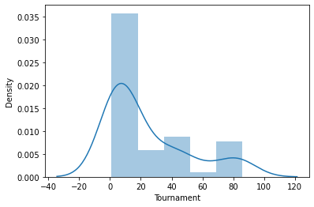

```python
#Total Tornaments played
sns.distplot(Basketball['Tournament'])
```

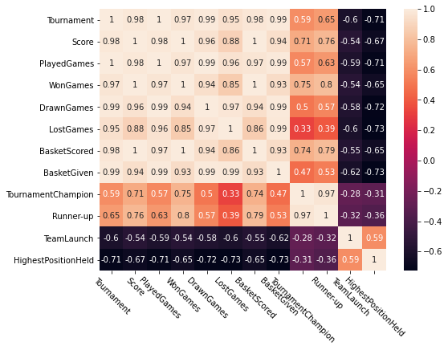

```python
# Heatmap helps us visualize matrix-like data in the form of hot and cold spots.
plt.figure(figsize=(8,6));
sns.heatmap(Basketball.corr(), annot=True);
plt.xticks(rotation=-45);
```

PART-3:

•DOMAIN: Startup ecosystem • CONTEXT: Company X is a EU online publisher focusing on the startups industry. The company specifically reports on the business related to technology news, analysis of emerging trends and profiling of new tech businesses and products. Their event i.e. Startup Battlefield is the world’s pre-eminent startup competition. Startup Battlefield features 15-30 top early stage startups pitching top judges in front of a vast live audience, present in person and online. • DATA DESCRIPTION: CompanyX_EU.csv - Each row in the dataset is a Start-up company and the columns describe the company. ATTRIBUTE INFORMATION:

1. Startup: Name of the company
2. Product: Actual product
3. Funding: Funds raised by the company in USD
4. Event: The event the company participated in
5. Result: Described by Contestant, Finalist, Audience choice, Winner or Runner up
6. OperatingState: Current status of the company, Operating ,Closed, Acquired or IPO *Dataset has been downloaded from the internet. All the credit for the dataset goes to the original creator of the data. • PROJECT OBJECTIVE: Analyse the data of the various companies from the given dataset and perform the tasks that are specified in the below steps. Draw insights from the various attributes that are present in the dataset, plot distributions, state hypotheses and draw conclusions from the dataset.

Steps and tasks: [ Total Score: 30 points]

1. Data warehouse: • Read the CSV file.
2. Data exploration: • Check the datatypes of each attribute. • Check for null values in the attributes.
3. Data preprocessing & visualisation: • Drop the null values. • Convert the ‘Funding’ features to a numerical value. • Plot box plot for funds in million. • Get the lower fence from the box plot. • Check number of outliers greater than upper fence. • Drop the values that are greater than upper fence. • Plot the box plot after dropping the values. • Check frequency of the OperatingState features classes. • Plot a distribution plot for Funds in million. • Plot distribution plots for companies still operating and companies that closed.
4. Statistical analysis: • Is there any significant difference between Funds raised by companies that are still operating vs companies that closed down? Write the null hypothesis and alternative hypothesis. Test for significance and conclusion • Make a copy of the original data frame. • Check frequency distribution of Result variable. • Calculate percentage of winners that are still operating and percentage of contestants that are still operating • Write your hypothesis comparing the proportion of companies that are operating between winners and contestants: Write the null hypothesis and alternative hypothesis. Test for significance and conclusion • Check distribution of the Event variable. • Select only the Event that has disrupt keyword from 2013 onwards. • Write and perform your hypothesis along with significance test comparing the funds raised by companies across NY, SF and EU events from 2013 onwards. • Plot the distribution plot comparing the 3 city events.
5. Write your observations on improvements or suggestions on quality, quantity, variety, velocity, veracity etc. on the data points collected to perform a better data analysis.

```python
# Load the necessary packages
# Already loaded at the begining
```

```python
# Load the CompanyX_EU Dataset

CompanyX = pd.read_csv('CompanyX_EU.csv')
```

```python
CompanyX.head()
```

|  | Startup | Product | Funding | Event | Result | OperatingState |
| --- | --- | --- | --- | --- | --- | --- |
| 0 | 2600Hz | 2600hz.com | NaN | Disrupt SF 2013 | Contestant | Operating |
| 1 | 3DLT | 3dlt.com | $630K | Disrupt NYC 2013 | Contestant | Closed |
| 2 | 3DPrinterOS | 3dprinteros.com | NaN | Disrupt SF 2016 | Contestant | Operating |
| 3 | 3Dprintler | 3dprintler.com | $1M | Disrupt NY 2016 | Audience choice | Operating |
| 4 | 42 Technologies | 42technologies.com | NaN | Disrupt NYC 2013 | Contestant | Operating |

```python
CompanyX.shape
```

```
(662, 6)
```

```python
#Print concise summary of Dataframe
#info() is used to check the Information about the data and the datatypes of each respective attribute.
CompanyX.info()
```

```
<class 'pandas.core.frame.DataFrame'>
RangeIndex: 662 entries, 0 to 661
Data columns (total 6 columns):
 #   Column          Non-Null Count  Dtype
---  ------          --------------  -----
 0   Startup         662 non-null    object
 1   Product         656 non-null    object
 2   Funding         448 non-null    object
 3   Event           662 non-null    object
 4   Result          662 non-null    object
 5   OperatingState  662 non-null    object
dtypes: object(6)
memory usage: 31.2+ KB
```

```python
# Generate descriptive statistics.
# Descriptive statistics include those that summarize the central tendency, dispersion and shape of a
# dataset's distribution, excluding ``NaN`` values
#The described method will help to see how data has been spread for numerical values.
# We can clearly see the minimum value, mean values, different percentile values, and maximum values.

CompanyX.describe(include="all")
```

|  | Startup | Product | Funding | Event | Result | OperatingState |
| --- | --- | --- | --- | --- | --- | --- |
| count | 662 | 656 | 448 | 662 | 662 | 662 |
| unique | 662 | 656 | 240 | 26 | 5 | 4 |
| top | Next Caller | alphaoutlook.com | $1M | TC50 2008 | Contestant | Operating |
| freq | 1 | 1 | 17 | 52 | 488 | 465 |

```python
# Handling missing value
# Check for missing value in any column
CompanyX.isnull().sum()
```

```
Startup             0
Product             6
Funding           214
Event               0
Result              0
OperatingState      0
dtype: int64
```

From the above reults we can clearly see that there are missing values in Product and Funding Columns.

We usually treat the null values with the following techniques:

1. Drop the missing values: In this case, we drop the missing values from those variables. In case there are very few missing values we can drop those values.
2. Impute with mean value: For the numerical column, we can replace the missing values with mean values. Before replacing with mean value, it is advisable to check that the variable shouldn’t have extreme values .i.e. outliers.
3. Impute with median value: For the numerical column, we can also replace the missing values with median values. In case we have extreme values such as outliers it is advisable to use the median approach.
4. Impute with mode value: For the categorical column, we can replace the missing values with mode values i.e the frequent ones.

```python
CompanyX = CompanyX.dropna().copy(deep=True)   # drop the rows which have no data for funds raised
```

```python
# All the null values are eliminated
CompanyX.isnull().sum()
```

```
Startup           0
Product           0
Funding           0
Event             0
Result            0
OperatingState    0
dtype: int64
```

```python
CompanyX.loc[:,'Funds_in_million'] = CompanyX['Funding'].apply(lambda x: float(x[1:-1])/1000 if x[-1] == 'K' else (float(x[1:-1])*1000 if x[-1] == 'B' else float(x[1:-1])))
```

```python
CompanyX.sample(3)
```

|  | Startup | Product | Funding | Event | Result | OperatingState | Funds_in_million |
| --- | --- | --- | --- | --- | --- | --- | --- |
| 210 | Gifi | gifi.fr | $1.2M | Disrupt SF 2010 | Contestant | Closed | 1.2 |
| 554 | Swype | swype.com | $15.6M | TC50 2008 | Finalist | Acquired | 15.6 |
| 422 | PlaySay | playsay.com | $1.1M | Disrupt SF 2011 | Contestant | Acquired | 1.1 |

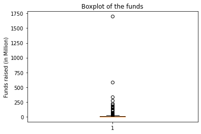

```python
%matplotlib inline
from matplotlib import pyplot as plt

plot = plt.boxplot(CompanyX.Funds_in_million)
plt.title('Boxplot of the funds')
plt.ylabel("Funds raised (in Million)")

plt.show()
```

```python
upper_fence = plot['caps'][1].get_data()[1][1]   # we can use the values from the box plot itself to get the upper fence
upper_fence
```

```
22.0
```

Looking at the box plot, it seems that the variables Funding, have outlier present in the variables. These outliers value needs to be teated and there are several ways of treating them:

Drop the outlier value Replace the outlier value using the IQR

```python
# def remove_outlier(col):
# Create a user defined function called remove_outlier for getting the threshold value from IQR

def remove_outlier(col):
    sorted(col)
    Q1, Q3=col.quantile([0.25,0.75])
    IQR=Q3-Q1
    lower_range=Q1-(1.5*IQR)
    upper_range=Q3+(1.5*IQR)
    return lower_range, upper_range
```

```python
# • Get the lower fence from the box plot.
# • Check number of outliers greater than upper fence.
# • Drop the values that are greater than upper fence.
# • Plot the box plot after dropping the values.
low_fund,up_fund=remove_outlier(CompanyX['Funds_in_million'])
print(up_fund)
print(low_fund)
```

```
22.569625
-12.349374999999998
```

```python
print(f'Number of outliers = {len(CompanyX[CompanyX.Funds_in_million > upper_fence])}')

CompanyX[CompanyX.Funds_in_million > upper_fence]
```

```
Number of outliers = 60
```

|  | Startup | Product | Funding | Event | Result | OperatingState | Funds_in_million |
| --- | --- | --- | --- | --- | --- | --- | --- |
| 6 | 8 Securities | 8securities.com | $29M | Disrupt Beijing 2011 | Finalist | Operating | 29.0 |
| 31 | Anyclip | anyclip.com | $24M | TC50 2009 | Finalist | Operating | 24.0 |
| 40 | Artsy | artsy.net | $50.9M | Disrupt NYC 2010 | Contestant | Operating | 50.9 |
| 49 | Badgeville | badgeville.com | $40M | Disrupt SF 2010 | Finalist | Acquired | 40.0 |
| 56 | Betterment | betterment.com | $205M | Disrupt NYC 2010 | Finalist | Operating | 205.0 |
| 108 | Clickable | clickable.com | $32.5M | TC40 2007 | Finalist | Acquired | 32.5 |
| 113 | Cloudflare | cloudflare.com | $182.1M | Disrupt SF 2010 | Runner up | Operating | 182.1 |
| 128 | Credit Sesame | creditsesame.com | $35.4M | Disrupt SF 2010 | Contestant | Operating | 35.4 |
| 130 | CrowdFlower Inc. | crowdflower.com | $38M | TC50 2009 | Contestant | Operating | 38.0 |
| 132 | Cubic Telecom | cubictelecom.com | $37.1M | TC40 2007 | Contestant | Operating | 37.1 |
| 138 | DataSift | datasift.com | $72M | Disrupt SF 2010 | Finalist | Operating | 72.0 |
| 139 | DataXu | dataxu.com | $64M | TC50 2009 | Contestant | Operating | 64.0 |
| 154 | Dropbox | dropbox.com | $1.7B | TC50 2008 | Contestant | Operating | 1700.0 |
| 166 | Enigma | enigma.io | $34.6M | Disrupt NYC 2013 | Winner | Operating | 34.6 |
| 172 | EverythingMe | everything.me | $35.5M | Disrupt NYC 2011 | Contestant | Closed | 35.5 |
| 179 | Famo.us | famo.us | $30.1M | Disrupt SF 2012 | Contestant | Operating | 30.1 |
| 180 | Farmigo | farmigo.com | $26M | Disrupt SF 2011 | Finalist | Operating | 26.0 |
| 188 | Fitbit | fitbit.com | $66M | TC50 2008 | Finalist | Ipo | 66.0 |
| 191 | Flock | flock.com | $28.3M | TC40 2007 | Contestant | Acquired | 28.3 |
| 209 | Getaround | getaround.com | $103M | Disrupt NYC 2011 | Winner | Operating | 103.0 |
| 213 | Gild | gild.com | $25.9M | Disrupt SF 2010 | Contestant | Acquired | 25.9 |
| 215 | Glide | glide.me | $36.5M | Disrupt NYC 2013 | Audience choice | Operating | 36.5 |
| 225 | Grockit | grockit.com | $44.7M | TC50 2008 | Finalist | Acquired | 44.7 |
| 231 | HackerRank | hackerrank.com | $24.2M | Disrupt SF 2012 | Contestant | Operating | 24.2 |
| 271 | Ionic Security | ionicsecurity.com | $122.4M | Disrupt SF 2012 | Contestant | Operating | 122.4 |
| 276 | IZEA | izea.com | $34.9M | Disrupt NYC 2010 | Contestant | Ipo | 34.9 |
| 279 | Jiff | jiff.com | $67.8M | Disrupt SF 2011 | Contestant | Acquired | 67.8 |
| 282 | Kaltura | kaltura.com | $166.1M | TC40 2007 | Audience choice | Operating | 166.1 |
| 302 | Layer | layer.com | $42.1M | Disrupt SF 2013 | Winner | Operating | 42.1 |
| 305 | LearnVest | learnvest.com | $69M | TC50 2009 | Contestant | Acquired | 69.0 |
| 313 | LiveIntent | liveintent.com | $65.1M | Disrupt NYC 2010 | Audience choice | Operating | 65.1 |
| 325 | Lystable | lystable.com | $25.1M | Disrupt London 2015 | Finalist | Operating | 25.1 |
| 346 | Mint | mint.com | $31.8M | TC40 2007 | Winner | Acquired | 31.8 |
| 389 | OrderWithMe | orderwithme.com | $37M | Disrupt Beijing 2011 | Winner | Operating | 37.0 |
| 393 | Osmo | playosmo.com | $38.5M | Disrupt SF 2013 | Contestant | Operating | 38.5 |
| 394 | Ossia | ossia.com | $25.5M | Disrupt SF 2013 | Runner up | Operating | 25.5 |
| 398 | Owlet Baby Care | owletcare.com | $24M | Hardware Battlefield 2014 | Runner up | Operating | 24.0 |
| 427 | Postmates | postmates.com | $278M | Disrupt SF 2011 | Contestant | Operating | 278.0 |
| 432 | Prism Skylabs | prism.com | $24M | Disrupt SF 2011 | Runner up | Operating | 24.0 |
| 435 | PubMatic | pubmatic.com | $63M | TC40 2007 | Contestant | Operating | 63.0 |
| 460 | Roadie | roadie.com | $25M | Disrupt NYC 2014 | Audience choice | Operating | 25.0 |
| 471 | SeatGeek | seatgeek.com | $160M | TC50 2009 | Contestant | Operating | 160.0 |
| 546 | StyleSeat | styleseat.com | $40M | Disrupt NYC 2011 | Contestant | Operating | 40.0 |
| 555 | Symphony Commerce | symphonycommerce.com | $47.4M | Disrupt NYC 2011 | Contestant | Operating | 47.4 |
| 560 | Talkdesk | talkdesk.com | $24.5M | Disrupt NYC 2012 | Contestant | Operating | 24.5 |
| 581 | TouchPal | touchpal.com | $25M | Disrupt Beijing 2011 | Finalist | Operating | 25.0 |
| 593 | TrueCar | truecar.com | $332.4M | TC50 2008 | Contestant | Ipo | 332.4 |
| 598 | UberConference | uberconference.com | $35M | Disrupt NYC 2012 | Winner | Operating | 35.0 |
| 606 | Upwork | upwork.com | $168.8M | TC50 2009 | Audience choice | Operating | 168.8 |
| 615 | VideoSurf | videosurf.com | $28M | TC50 2008 | Contestant | Acquired | 28.0 |
| 625 | Voxy | voxy.com | $30.8M | Disrupt SF 2010 | Contestant | Operating | 30.8 |
| 643 | Xobni | yahoo.com | $41.8M | TC40 2007 | Contestant | Acquired | 41.8 |
| 644 | Yammer | yammer.com | $142M | TC50 2008 | Winner | Acquired | 142.0 |
| 647 | Yext | yext.com | $117.8M | TC50 2009 | Contestant | Ipo | 117.8 |
| 649 | YouNow | younow.com | $26M | Disrupt SF 2011 | Contestant | Operating | 26.0 |
| 650 | YourMechanic | yourmechanic.com | $28M | Disrupt SF 2012 | Winner | Operating | 28.0 |
| 654 | ZEFR | zefr.com | $62.1M | Disrupt NYC 2010 | Contestant | Operating | 62.1 |
| 656 | Zenefits | zenefits.com | $583.6M | Disrupt NYC 2013 | Finalist | Operating | 583.6 |
| 659 | Zocdoc | zocdoc.com | $223M | TC40 2007 | Contestant | Operating | 223.0 |
| 661 | Zumper | zumper.com | $31.5M | Disrupt SF 2012 | Finalist | Operating | 31.5 |